# Reproducible Research Peer Assessment 2

Jansen Ng

### Read files and load libraries

- The *repdata-data-StormData.csv* file is read into the variable *stormData*

```r
stormData <- read.table(file="repdata-data-StormData.csv", sep=",", stringsAsFactors=FALSE, header=TRUE, na.strings=c("", "NA"))
```

- The packages *dplyr*, *ggplot2*, *reshape2* are loaded

```r
library(dplyr)
```

```r
library(reshape2)
library(ggplot2)
```

## Most Dangerous to Population Health

### Data Processing

- The 2 variables which contain information about harm or damage to human health are *FATALITIES* and *INJURIES*.
- A subset of the *stormData* dataset containing *EVTYPE*, *FATALITIES*, *INJURIES* is created, then the sum of fatalities and injuries are aggregated by evtype.
- The resulting data frame is then separately arranged in descending order of total fatalities and total injuries.

```r
popHealth <- stormData %>% select(EVTYPE, FATALITIES, INJURIES)
popHealth$EVTYPE <- as.factor(popHealth$EVTYPE)
ph1 <-  popHealth %>% group_by(EVTYPE) %>%
          summarize(total.fatalities=sum(FATALITIES), total.injuries=sum(INJURIES))
ph1.fatalities <- ph1 %>% arrange(desc(total.fatalities))
ph1.injuries <- ph1 %>% arrange(desc(total.injuries))
```

### Results

#### Highest total fatalities

The top 5 storm event types are as follows:

```r
head(ph1.fatalities, n=5)
```

```
## Source: local data frame [5 x 3]
##
##           EVTYPE total.fatalities total.injuries
## 1        TORNADO             5633          91346
## 2 EXCESSIVE HEAT             1903           6525
## 3    FLASH FLOOD              978           1777
## 4           HEAT              937           2100
## 5      LIGHTNING              816           5230
```

#### Highest total injuries

The top 5 storm event types are as follows:

```r
head(ph1.injuries, n=5)
```

```
## Source: local data frame [5 x 3]
##
##           EVTYPE total.fatalities total.injuries
## 1        TORNADO             5633          91346
## 2      TSTM WIND              504           6957
## 3          FLOOD              470           6789
## 4 EXCESSIVE HEAT             1903           6525
## 5      LIGHTNING              816           5230
```

### Conclusion

As the storm event type tornado gives the highest total fatalities as well as total injuries, the storm event type most dangerous to human health is the tornado.

## Greatest Economic Consequences across the United States

### Data Processing

```r
ecDmg <- stormData %>% select(EVTYPE, PROPDMG, PROPDMGEXP, CROPDMG, CROPDMGEXP)
ecDmg$EVTYPE <- as.factor(ecDmg$EVTYPE)
ecDmg <- ecDmg %>% mutate(
  p.multip=ifelse(PROPDMGEXP=="B", 1e+09, ifelse(PROPDMGEXP=="M", 1e+06, ifelse(PROPDMGEXP=="K", 1000, NA))),
  c.multip=ifelse(CROPDMGEXP=="B", 1e+09, ifelse(CROPDMGEXP=="M", 1e+06, ifelse(CROPDMGEXP=="K", 1000, NA))))
```

#### Damage to Crops

Create dataset of storm event type in decreasing magnitude of damage to crops

```r
ecDmg.c <- ecDmg %>% select(EVTYPE, CROPDMG, c.multip) %>%
  filter(is.na(c.multip)==FALSE) %>%
  mutate(crop.dmg=CROPDMG*c.multip) %>%
  select(EVTYPE, crop.dmg) %>%
  group_by(EVTYPE) %>%
  summarize(total.crop.dmg=sum(crop.dmg)) %>%
  arrange(desc(total.crop.dmg))
```

#### Damage to Property

Create dataset of storm event type in decreasing magnitude of damage to property

```r
ecDmg.p <- ecDmg %>% select(EVTYPE, PROPDMG, p.multip) %>%
  filter(is.na(p.multip)==FALSE) %>%
  mutate(prop.dmg=PROPDMG*p.multip) %>%
  select(EVTYPE, prop.dmg) %>%
  group_by(EVTYPE) %>%
  summarize(total.prop.dmg=sum(prop.dmg)) %>%
  arrange(desc(total.prop.dmg))
```

### Results

Subset top 10 events to property and crops

```r
cDmgTop10 <- subset(ecDmg.c[1:10,])
pDmgTop10 <- subset(ecDmg.p[1:10,])
```

#### Most Damage to Crops

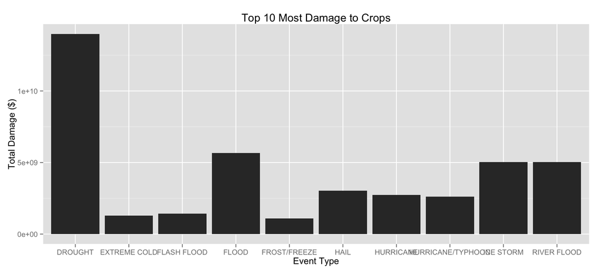

```
## Source: local data frame [10 x 2]
##
##               EVTYPE total.crop.dmg
## 1            DROUGHT    13972566000
## 2              FLOOD     5661968450
## 3        RIVER FLOOD     5029459000
## 4          ICE STORM     5022113500
## 5               HAIL     3025537450
## 6          HURRICANE     2741910000
## 7  HURRICANE/TYPHOON     2607872800
## 8        FLASH FLOOD     1421317100
## 9       EXTREME COLD     1292973000
## 10      FROST/FREEZE     1094086000
```

```r
cDmgTop10

ggplot(cDmgTop10, aes(x=factor(EVTYPE), y=total.crop.dmg)) +
  geom_bar(stat="identity") +
  ggtitle("Top 10 Most Damage to Crops") +
  ylab("Total Damage ($)") + xlab("Event Type")
```

#### Most Damage to Property

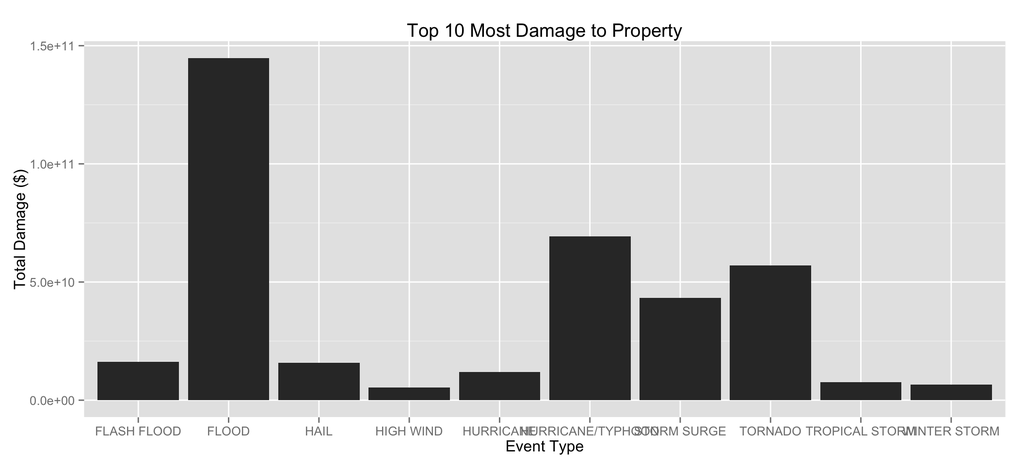

```
## Source: local data frame [10 x 2]
##
##               EVTYPE total.prop.dmg
## 1              FLOOD   144657709800
## 2  HURRICANE/TYPHOON    69305840000
## 3            TORNADO    56925660480
## 4        STORM SURGE    43323536000
## 5        FLASH FLOOD    16140811510
## 6               HAIL    15727366720
## 7          HURRICANE    11868319010
## 8     TROPICAL STORM     7703890550
## 9       WINTER STORM     6688497250
## 10         HIGH WIND     5270046260
```

```r
pDmgTop10

ggplot(pDmgTop10, aes(x=factor(EVTYPE), y=total.prop.dmg)) +
  geom_bar(stat="identity") +
  ggtitle("Top 10 Most Damage to Property") +
  ylab("Total Damage ($)") + xlab("Event Type")
```

### Conclusion

Based on the above plots and the data for the damage to property and crops, the most devastating storm event to the economy is the flood.